# STAT2401 Analysis of Experiments

Practical 1: SOLUTION

**Aims of this session**

This practical session has the following objectives:

1. to introduce you to R/RStudio/Rmarkdown using Computer Lab 0 documentation
2. to introduce you to do loading, exploring and visualising data
3. to review standard normal and t distributions
4. to perform statistical inference (hypothesis testing and confidence intervals) using *2 sample t-test*
   - Introduction to Rmarkdown is provided under Practical 0. Please complete the exercises or questions within before this Practical 1.
   - Partial solutions are provided for Exercises 3-6 only, which will be available after the session. Please independently attempt the questions during the session, by consulting to the faciltators.

# 1 Introduction

## 1.1 An Important Note

This document contains some notes on the exercises in the first computer lab. When reading the data into *R*, we assume that the relevant files are stored in a subdirectory, and that you have set the working directory to that in *R*. This can be done with the *setwd()* command. I.e.~ you may have to modify the commands with which the data is read in, but all other commands should work as shown, and they should produce the shown output.

Some general notes: When typing in *R* commands you can use the arrow keys to speed things up. The `up’ arrow gives you the previous command that you typed. The usual prompt sign for *R* is $>$. If you get a + prompt sign instead, it means that *R* is awaiting the completion of the previous command that you typed in. This can happen because you have forgotten to close parentheses, for instance. Just type in the remainder of the command. Note also that *R* is case sensitive.

Introduction to Rmarkdown is provided under Computer Lab 0. Please complete the exercises or questions within before this Lab 1.

## 1.2 Required Software

For the purposes of this unit you will need to make sure you have three things on your computer:

- *R*: All of the labs and other assessed tasks in this unit will make use of the [statistical computing language *R* ((https://www.r-project.org/)). You will need *R* installed on your computer, which can be achieved by downloading it from the following link: (https://cran.ms.unimelb.edu.au/).
- *Rstudio*: We will also use the [*RStudio* IDE] ((https://rstudio.com/)). Please download the open source (free) edition of *RStudio* Desktop from the following link: (https://rstudio.com/products/RStudio/)
- All required packages installed OR administrator privileges to install them: Additionally, some of the labs there may be some packages you will need installed. For these purposes you will either need to make sure you have administrator privileges on your computer or that these packages have been previously installed on your computer by an administrator user.

Take this time to make sure you have access to and are familiar with the basics of how to use this software.

## 1.3 Reading Data

For those familiar with working in the command line, the *R* working directory is the same concept. This is a key concept for interacting with files outside of the *R* instance as it determines the location in the filesystem for relative paths. This is important when reading in data from a file, for example. The working directory can be checked and changed using *getwd()* and *setwd()* respectively.

However, we suggest that when you do some work that you start a new project in *RStudio* in a folder for that chunk of work (for example you might choose to make a separate project (i.e. directory) for each lab, assignment, etc. ). This essentially will tell {RStudio{ to set the working directory to the directory associated to that bit of work when you open that project, and avoids a lot of “file not found” errors beginners often run into.

## 1.4 Help

It will be crucial that you learn to read *R* documentation. You may be asked to use an *R* function and in order to be able to do so you will need to be able to read and at least partly understand the documentation. For example, if you are told to use the function {mean(){, you would type:

```r
`?`(mean)
```

into your *R* command line (in *RStudio* this appears in the Console tab), and this will bring up the documentation for that function (in *RStudio* this documentation will appear in the Help tab). Try reading the documentation for the function *mean()* right now as an exercise and see if you can figure out what it’s optional arguments would be used for. If you can’t yet, come back to this exercise at the end of the lab once you’ve had a bit more of a play and it might make more sense.

# 2 Exercise 1: Loading, Exploring, and Visualising Data

We will use the *njgolf* data to illustrate some basic functions in *R*. The data was used to study the impacts of golf course proximity on home prices, from Asabere and Huffman (1996) [Asabere, P.K. and Huffman, F.E. (1996) Negative and positive impacts of golf course proximity on home prices. Appraisal Journal 64(4), 351-355.].

The data *njgolf* contains some of the variables for our illustration, they are:

```
      - selling price (*sprice*).
      - lot size (*lotsize*)
      - Number of bed rooms (*beds*),
      - Dining Room Area (*drarea*),
      - Kitchen Area (*kitarea*), and
      - type of the property (*lotsizef*, condominium (*con*), house (*house*), townhouse (*th*)).
```

for 105 single-family homes in Mount Laurel, New Jersey, from March 1992 through September 1994.

For our information, we note that the variable labeled *lotsize* is actually a conflation of two distinct concepts. If the property is a condominium (a form of ownership of an apartment that combines single ownership of the residence unit with joint ownership of the building and associated grounds), the variable *lotsize* was arbitrarily coded to 0. If the property is a single-family house, then the variable *lotsize* contains the actual lot size in square feet. This explains the numerous observations having *lotsize=0* in the data.

In some of practicals, we will use the following packages. If any of these packages are missing on your computer, please install them (and their dependencies) using the *install.packages()* command or the *Install* option in the *Packages* tab of *RStudio*. Once these packages are installed

```r
# For making pretty graphs, part of tidyverse install.packages('tidyverse')
library("ggplot2")
```

```r
# For combining ggplot2 objects in intuitive (and magical) ways
library("patchwork")
```

## 2.1 Loading Data

We will demonstrate how to read it in from a CSV (comma separated values) file, which is available for download from LMS. Then so long as you have set up your “Working Directory” and put the file *njgolf.csv* in the directory, the following line of code will read the data into *R* as a {data.frame{ object named *njgolf*.

```r
njgolf = read.csv("njgolf.csv", header = TRUE)
View(njgolf)  # to view the dataset
dim(njgolf)  # how many rows and columns
```

```
[1] 105   6
```

## 2.2 data.frames in *R*

In the previous section we read in the *njgolf* data from a CSV file into a global environment variable named *njgolf* of type *data.frame*. Check out the documentation for *?data.frame* as this is the standard way to store data in *R*.

*head()* is a useful command for taking a look at a data.frame:

```r
head(njgolf)
```

```
  sprice lotsize beds drarea kitarea lotsizef
1 145000    8970    4    132     144    house
2 175000    9375    5    180     180    house
3 157000    7920    4    156     169    house
4  68000       0    2     72      88      con
5 142000   10080    3    108     126    house
6 144750   10295    4    143     234    house
```

Try using *tail()* in the same way as *head()*, what does it do? By reading the documentation and/ or trying it, what does providing the optional argument {n{ to these functions do? *head(df)* prints the first *n* (default 6) lines of *df*, while *tail(df)* prints the last *n*. Individual and ranges of entries of a data.frame can be accessed by their indices and columns can be identified by their headers. See some examples:

```r
njgolf[3, 2]
```

```
[1] 7920
```

```r
njgolf[2:4, 3]
```

```
[1] 5 4 2
```

```r
njgolf[3, 2:4]
```

```
  lotsize beds drarea
3    7920    4    156
```

```r
njgolf[3, "sprice"]
```

```
[1] 157000
```

```r
njgolf[c(2:4, 90:92), c("sprice", "beds")]
```

```
   sprice beds
2  175000    5
3  157000    4
4   68000    2
90 166000    4
91 158000    3
92  65500    2
```

Columns of a *data.frame* can also be accessed with the *$* operator, in which case the column name needs to not be quoted, or as a list in which case it does, and entries from these vectors can then also be returned:

```r
njgolf$sprice[2:4]
```

```
[1] 175000 157000  68000
```

```r
njgolf[["sprice"]][2:4]
```

```
[1] 175000 157000  68000
```

Note the single square braces for accessing entries in vectors/matrices and the double square braces for accessing entries in lists, this is *R* syntax and because *data.frame* objects share properties of both matrices and lists they can be manipulated in both ways.

## 2.3 Exploring and Visualising

*str()* and *summary()* are useful functions for exploring an object:

```r
str(njgolf)
```

```
'data.frame':   105 obs. of  6 variables:
 $ sprice  : int  145000 175000 157000 68000 142000 144750 90200 154000 150000 96700 ...
 $ lotsize : int  8970 9375 7920 0 10080 10295 0 25200 8820 0 ...
 $ beds    : int  4 5 4 2 3 4 2 4 4 1 ...
 $ drarea  : int  132 180 156 72 108 143 72 156 143 80 ...
 $ kitarea : int  144 180 169 88 126 234 72 210 156 99 ...
 $ lotsizef: chr  "house" "house" "house" "con" ...
```

```r
summary(njgolf)
```

```
     sprice          lotsize           beds           drarea
 Min.   : 57900   Min.   :    0   Min.   :1.000   Min.   : 64.0
 1st Qu.: 96700   1st Qu.:    0   1st Qu.:2.000   1st Qu.: 99.0
 Median :143500   Median : 9000   Median :4.000   Median :132.0
 Mean   :135540   Mean   : 6900   Mean   :3.181   Mean   :123.8
 3rd Qu.:166000   3rd Qu.:10792   3rd Qu.:4.000   3rd Qu.:144.0
 Max.   :235000   Max.   :28286   Max.   :5.000   Max.   :192.0
                                                  NA's   :6
    kitarea        lotsizef
 Min.   : 64.0   Length:105
 1st Qu.: 99.0   Class :character
 Median :144.0   Mode  :character
 Mean   :151.2
 3rd Qu.:193.5
 Max.   :286.0
 NA's   :9
```

For visualisation, some important plotting functions are *plot()*, *hist()*, and *boxplot()*. *plot()* is a generic function, similar to *summary()* and will have very different behaviour for different inputs, for example you can provide the variables you want plotted in *x* and *y* axes:

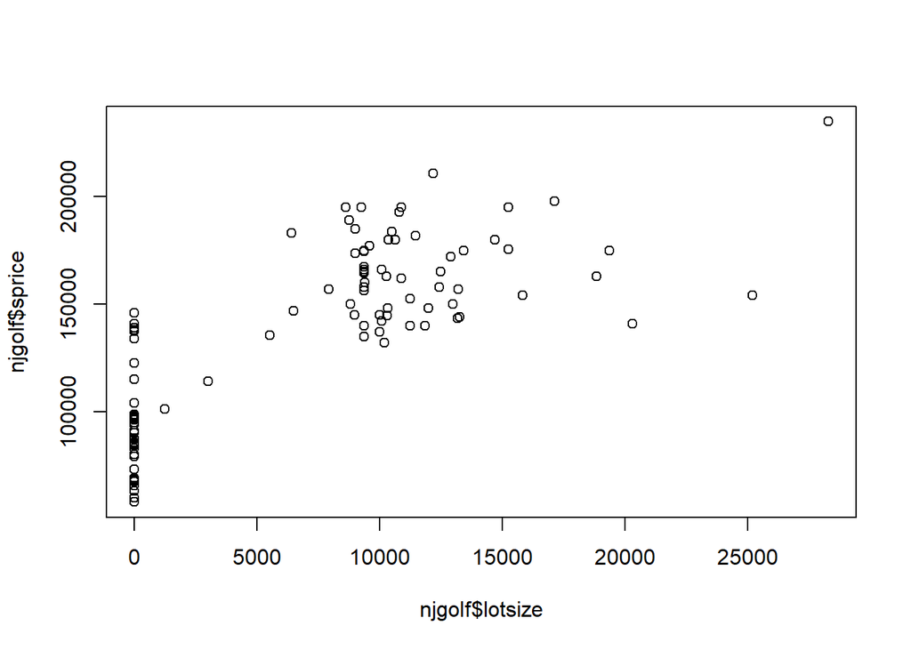

```r
plot(njgolf$lotsize, njgolf$sprice)
```

We can add a distinguishing feature like this:

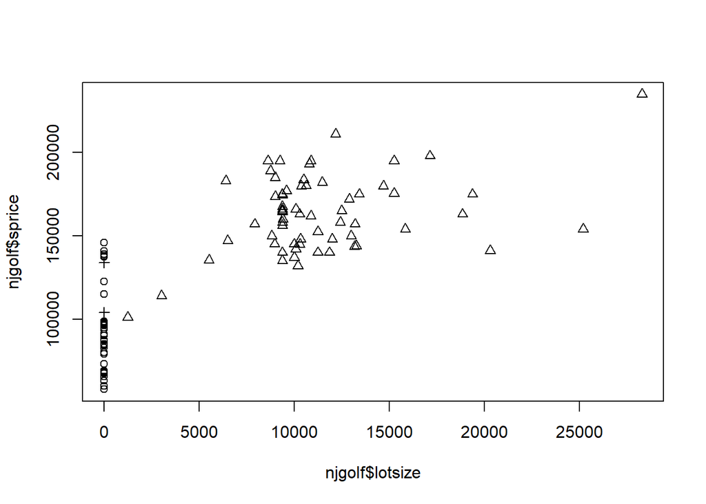

```r
plot(njgolf$lotsize, njgolf$sprice, pch = as.numeric(factor(njgolf$lotsizef)))
```

More detail on methods for modifying plots can be found on the very helpful *?par* page.

Another interesting feature of *plot()* is that if you simply give it an entire *data.frame* the default behaviour is to make what is called a *pairs* plot, however it needs all the variables to be numeric. So we can just give it the first three variables and differentiate the types of the properties like this:

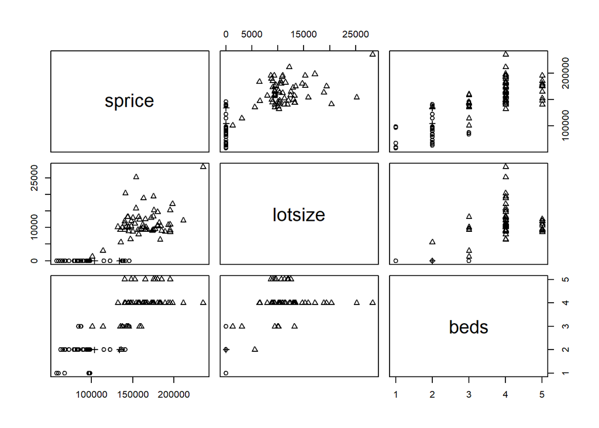

```r
plot(njgolf[, 1:3], pch = as.numeric(factor(njgolf$lotsizef)))
```

*hist()* and *boxplot* are also useful for making histograms and boxplots, see for example:

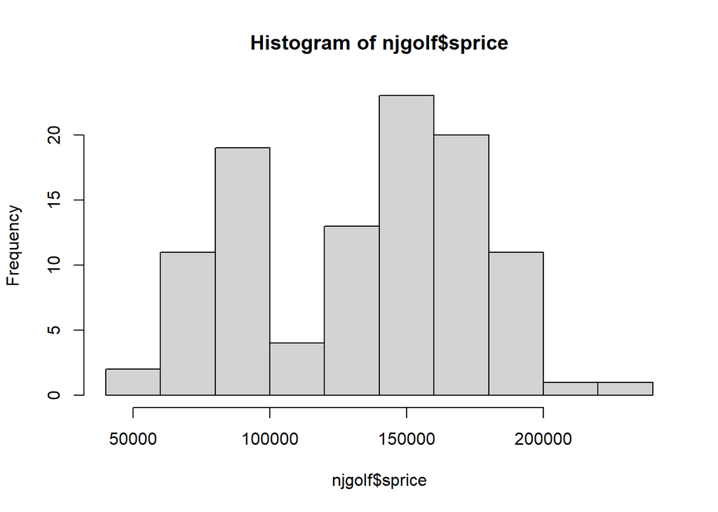

```r
hist(njgolf$sprice)
```

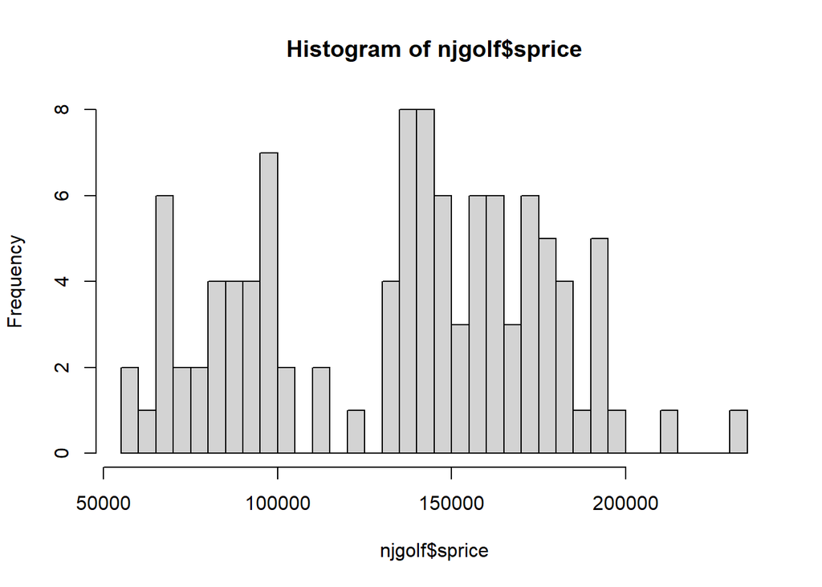

```r
hist(njgolf$sprice, 50)
```

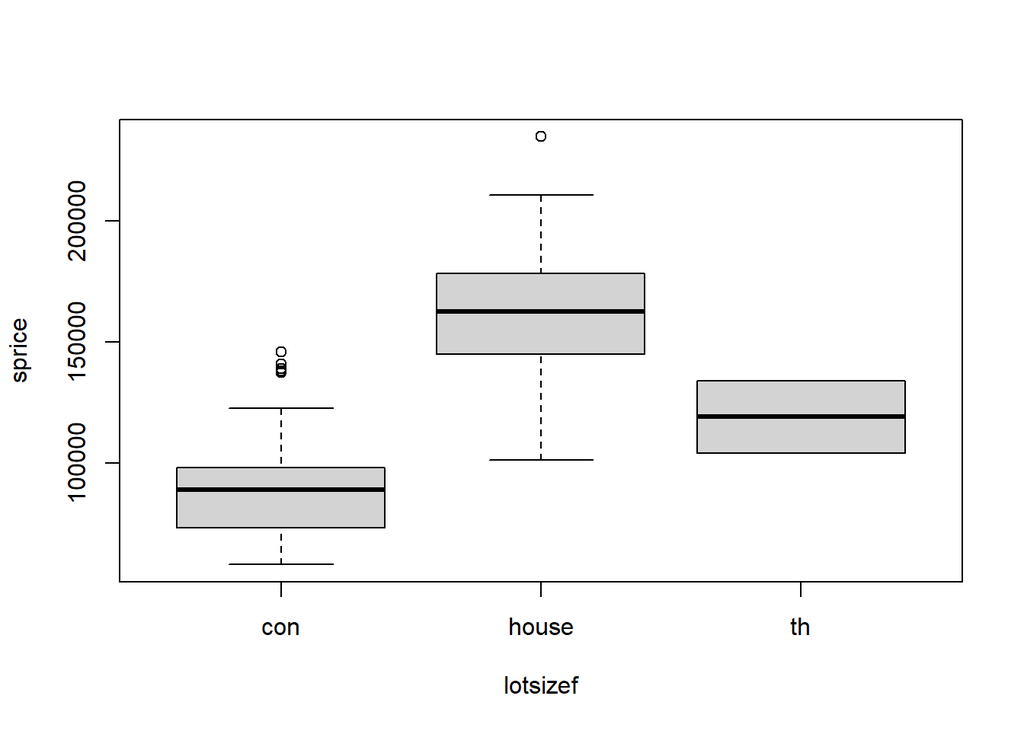

```r
boxplot(sprice ~ lotsizef, data = njgolf)
```

Try producing some boxplots and histograms for the dataset.

```
 - What are some of the key decisions you need to make when doing so?
```

Hint: compare the two histograms above. How might you go about making these decisions, and what impact do you think they could have on your conclusions?

```
- What information can you get from a boxplot that is not available in a histogram?

- What information can you get from a histogram that is not available in a boxplot?
```

Note that the *~* in the boxplot command, this is *R* syntax for defining formula’s — see the documentation *?formula*. These will be important later as they are the most common way to define models (such as linear regression models for example) in *R*.

# 3 Exercise 2 Getting to know the data from R package - Gapminder data

The dataset we’ll use is a subset of the demographic, health, employment, and economic data available for many countries on the [Gapminder](http://www.gapminder.org) website. It is contained in the *R* package `gapminder`, that you *may* be able to install on the PC you’re using in the computer lab. You can do so from either the *RStudio* menu (`Tools -> Install Packages`), or by invoking the following command in the console:

```r
# Do not write this in a chunk! You don't want to install a package every time
# you process an R Markdown file!
install.packages("gapminder", repos = "https://cran.curtin.edu.au")
```

Then, to load this package, invoke the command

```r
library(gapminder)
```

## 3.1 Getting to know the data

There is, in fact, quite a sophisticated set of packages for manipulating (or ‘wrangling’) data known as the [tidyverse](http://tidyverse.org/), but we’ll be using a much simpler set of built-in commands in *R*. Keep in mind that there are many ways to get to the same result in *R*!

Imagine that you have been asked to explore the impact of demographic and economic variables over time on life expectancy in many different countries. One of the first activities of a data scientist is to get to know the data *before* trying to construct any statistical models.

The questions you ask in order to get to know the data are specific to the dataset itself, but finding out basic characteristics of the dataset will be common to all analyses: how big, how many variables, which variables, and so on.

## 3.2 Questions

**Keep in mind that there are several ways of doing the same thing in *R*.**

1. How big is the dataset?

```r
# In RStudio, you can have a look at the 'Environment' tab, which will give you
# information about objects in the workspace, but you could also use the
# following function:

dim(gapminder)  # gives number of rows and columns of a data frame
```

```
[1] 1704    6
```

2. How many variables are in the dataset? What are they?

```r
# There are six, as we saw above. The function 'colnames' will give us the
# variable names:

colnames(gapminder)
```

```
[1] "country"   "continent" "year"      "lifeExp"   "pop"       "gdpPercap"
```

3. How would you examine the first and last few rows of the dataset?

```r
# You could look a them using the viewer from the 'Environment' tab, or you
# could try this:

head(gapminder)
```

```
# A tibble: 6 × 6
  country     continent  year lifeExp      pop gdpPercap
  <fct>       <fct>     <int>   <dbl>    <int>     <dbl>
1 Afghanistan Asia       1952    28.8  8425333      779.
2 Afghanistan Asia       1957    30.3  9240934      821.
3 Afghanistan Asia       1962    32.0 10267083      853.
4 Afghanistan Asia       1967    34.0 11537966      836.
5 Afghanistan Asia       1972    36.1 13079460      740.
6 Afghanistan Asia       1977    38.4 14880372      786.
```

```r
tail(gapminder)
```

```
# A tibble: 6 × 6
  country  continent  year lifeExp      pop gdpPercap
  <fct>    <fct>     <int>   <dbl>    <int>     <dbl>
1 Zimbabwe Africa     1982    60.4  7636524      789.
2 Zimbabwe Africa     1987    62.4  9216418      706.
3 Zimbabwe Africa     1992    60.4 10704340      693.
4 Zimbabwe Africa     1997    46.8 11404948      792.
5 Zimbabwe Africa     2002    40.0 11926563      672.
6 Zimbabwe Africa     2007    43.5 12311143      470.
```

4. What is the class of each of the variables? In other words, what types of variables are they?

```r
# The function 'str` (short for structure) is very useful! It'll tell you
# variable types: numeric, either continuous or integer, categorical variables,
# or factors, etc.

str(gapminder)
```

```
tibble [1,704 × 6] (S3: tbl_df/tbl/data.frame)
 $ country  : Factor w/ 142 levels "Afghanistan",..: 1 1 1 1 1 1 1 1 1 1 ...
 $ continent: Factor w/ 5 levels "Africa","Americas",..: 3 3 3 3 3 3 3 3 3 3 ...
 $ year     : int [1:1704] 1952 1957 1962 1967 1972 1977 1982 1987 1992 1997 ...
 $ lifeExp  : num [1:1704] 28.8 30.3 32 34 36.1 ...
 $ pop      : int [1:1704] 8425333 9240934 10267083 11537966 13079460 14880372 12881816 13867957 16317921 22227415 ...
 $ gdpPercap: num [1:1704] 779 821 853 836 740 ...
```

5. How many countries are represented?

```r
# From above, there are 142 countries. Or else we could work out the number of
# unique elements of the vector gapminder$country:

length(unique(gapminder$country))
```

```
[1] 142
```

6. How many continents are represented?

```r
# Same as above

length(unique(gapminder$continent))
```

```
[1] 5
```

7. Create a new dataset containing only the data for Australia.

```r
# It is essential to know how to subset a larger data structure. The subset
# command is very useful!  Note that the value of the argument 'subset' has to
# be a logical vector

Oz <- subset(gapminder, subset = (country == "Australia"))
Oz
```

```
# A tibble: 12 × 6
   country   continent  year lifeExp      pop gdpPercap
   <fct>     <fct>     <int>   <dbl>    <int>     <dbl>
 1 Australia Oceania    1952    69.1  8691212    10040.
 2 Australia Oceania    1957    70.3  9712569    10950.
 3 Australia Oceania    1962    70.9 10794968    12217.
 4 Australia Oceania    1967    71.1 11872264    14526.
 5 Australia Oceania    1972    71.9 13177000    16789.
 6 Australia Oceania    1977    73.5 14074100    18334.
 7 Australia Oceania    1982    74.7 15184200    19477.
 8 Australia Oceania    1987    76.3 16257249    21889.
 9 Australia Oceania    1992    77.6 17481977    23425.
10 Australia Oceania    1997    78.8 18565243    26998.
11 Australia Oceania    2002    80.4 19546792    30688.
12 Australia Oceania    2007    81.2 20434176    34435.
```

8. Calculate the increase in average life expectancy for Australians over the time period in the dataset.

```r
# Clearly, the data is organized in time order, so we need only subtract the
# first from the last element of the vector Oz$lifeExp. (Try it!) More
# generally, however, if the rows weren't in time order, you could do something
# like this (again, work it out):

Oz$lifeExp[which.max(Oz$year)] - Oz$lifeExp[which.min(Oz$year)]
```

```
[1] 12.115
```

9. Produce pairwise scatterplots of the three numerical variables for Australia.

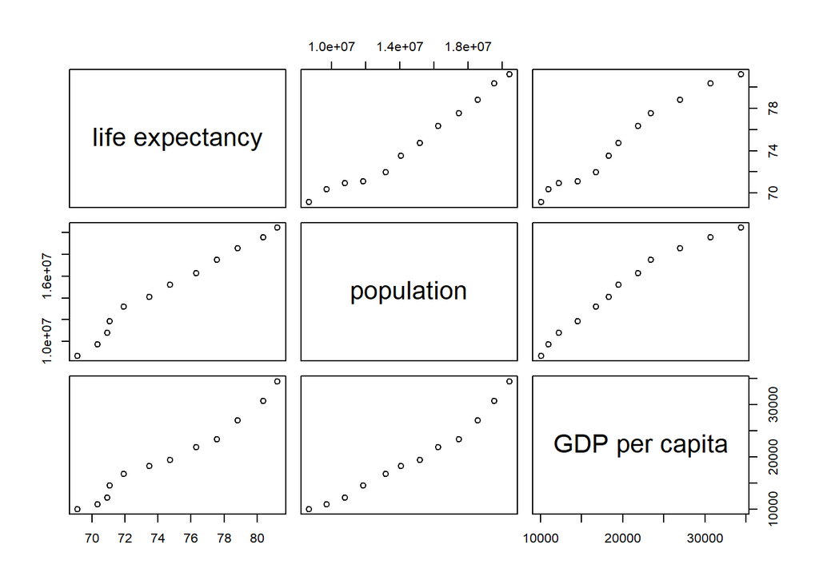

```r
# We need to extract the variables lifeExp, pop, and gdpPercap from the data
# for Australia, and then use the function 'plot'. Lot's of ways to do it;
# here's one (what would happen if I didn't add the 'labels' argument?)

plot(subset(Oz, select = c(lifeExp, pop, gdpPercap)), labels = c("life expectancy",
    "population", "GDP per capita"))
```

10. What is the increase in life expectancy for Burundi?

```r
# You could do the same thing we did for Australia

Burundi <- subset(gapminder, subset = (country == "Burundi"))
Burundi$lifeExp[which.max(Burundi$year)] - Burundi$lifeExp[which.min(Burundi$year)]
```

```
[1] 10.549
```

```r
which(gapminder$country == "Burundi")
```

```
 [1] 205 206 207 208 209 210 211 212 213 214 215 216
```

12. How would you create a dataset that contains only the data for 2007 for all countries?

```r
# Again, we could use the function 'subset':
Data2007 <- subset(gapminder, subset = (year == 2007))
```

13. Which country had the lowest life expectancy in 2007? Which had the highest?

```r
# Here, we simply find the row corresponding to the min/max life expectancy,
# and then use that index to select and display the corresponding row of the
# data object for 2007
Data2007[which.min(Data2007$lifeExp), ]
```

```
# A tibble: 1 × 6
  country   continent  year lifeExp     pop gdpPercap
  <fct>     <fct>     <int>   <dbl>   <int>     <dbl>
1 Swaziland Africa     2007    39.6 1133066     4513.
```

```r
Data2007[which.max(Data2007$lifeExp), ]
```

```
# A tibble: 1 × 6
  country continent  year lifeExp       pop gdpPercap
  <fct>   <fct>     <int>   <dbl>     <int>     <dbl>
1 Japan   Asia       2007    82.6 127467972    31656.
```

14. What is the mean GDP per capita in each country?

```r
# Hint: use the function 'tapply' on the vector gapminder$gdpPercap
MeanGDP <- tapply(gapminder$gdpPercap, gapminder$country, mean)
head(MeanGDP)
```

```
Afghanistan     Albania     Algeria      Angola   Argentina   Australia
   802.6746   3255.3666   4426.0260   3607.1005   8955.5538  19980.5956
```

# 4 Exercise 3 Calculating Standard Normal probabilities

Hint: use ?pnorm, ?qnorm

1. Let $Z$ be a standard normal random variable.

   ```
     -  What is the probability that $Z>2$? Compute this probability using {pnorm} in {R}.
   ```

```r
1 - pnorm(2)  ## or 1-pnorm(2,0,1)
```

```
[1] 0.02275013
```

```
     -  Determine $c$ that $P(Z>c)=0.05$. Compute $c$ using  {qnorm} in {R}.
```

```r
c = qnorm(1 - 0.05)  ## or qnorm(1-0.05,0,1)
c
```

```
[1] 1.644854
```

```
     -  What is the probability that $Z$ is dropped in the interval $(-c,c)$, $P(-c<Z<c)$? ($c$ is the constant in part (b))
```

```r
pnorm(c) - pnorm(-c)
```

```
[1] 0.9
```

2. Let $Y_1,\ldots,Y_n$ be a random sample of size $n$. All $Y_i$s are independent and have finite mean $\mu$ and variance $\sigma^2$.
- Which law or theorem says that the sample mean $\frac{1}{n}\sum_{i=1}^n Y_i$ would converge to $\mu$ when $n$ is large?

Answer: Law of large number

- Take $\mu=0$ and $\sigma^2=1$. Which law or theorem says that $\frac{1}{\sqrt{n}}\sum_{i=1}^n Y_i$ would closely follow normal distribution when $n$ is large?

Answer: Central Limit Theorem

3. Let $Y_1,\ldots,Y_n$ be a normal random sample of size $n$. All $Y_i$s are independent normal variables and have finite mean $\mu$ and variance $\sigma^2$.
- What distribution this term $\frac{\bar Y-\mu}{\sqrt{\frac{\sigma^2}{n}}}$ would follow? ($\bar Y=\frac{1}{n}\sum_{i=1}^n Y_i$ is the sample mean)

Answer: Normal distribution, because it is the linear combination of normal random variables

- What distribution this term $\frac{\bar Y-\mu}{\sqrt{\frac{S^2}{n}}}$ would follow? ($S^2=\frac{1}{n-1}\sum_{i=1}^n (Y_i-\bar Y)^2$ is the sample variance)

Answer: $t$ distribution with degree of freedom $n-1$

# 5 Exercise 4 T- distribution

Let $T_\nu$ be a $t$ random variable with $\nu$ degree of freedom.

Hint. Use ?pt, ?qt

1. What is the probability that $T_5>2$? Compute this probability using {pt} in {R}.

```r
1 - pt(2, 5)
```

```
[1] 0.05096974
```

2. Determine $c$ that $P(T_5>c)=0.05$. Compute $c$ using {qt} in {R}.

```r
c = qt(1 - 0.05, 5)
c
```

```
[1] 2.015048
```

3. What is the probability that $T_5$ is dropped in the interval $(-c,c)$, $P(-c<T_5<c)$? ($c$ is the constant in part (b))

```r
pt(c, 5) - pt(-c, 5)
```

```
[1] 0.9
```

# 6 Exercise 5: Matrix computation using R

The function *matrix* creates matrices in R:

*matrix(data, nrow, ncol, byrow)*

1. Create two matrices ( *mat1* and *mat2* ) of size 5x5 of 25 random numbers from a standard normal distribution.

```r
set.seed(1234)
mat1 = matrix(data = rnorm(25, 0, 1), nrow = 5, ncol = 5)
mat2 = matrix(data = rnorm(25, 0, 1), nrow = 5, ncol = 5)
mat1
```

```
           [,1]       [,2]        [,3]       [,4]       [,5]
[1,] -1.2070657  0.5060559 -0.47719270 -0.1102855  0.1340882
[2,]  0.2774292 -0.5747400 -0.99838644 -0.5110095 -0.4906859
[3,]  1.0844412 -0.5466319 -0.77625389 -0.9111954 -0.4405479
[4,] -2.3456977 -0.5644520  0.06445882 -0.8371717  0.4595894
[5,]  0.4291247 -0.8900378  0.95949406  2.4158352 -0.6937202
```

```r
mat2
```

```
           [,1]       [,2]       [,3]       [,4]       [,5]
[1,] -1.4482049  1.1022975 -1.1676193  1.4494963 -0.9685143
[2,]  0.5747557 -0.4755931 -2.1800396 -1.0686427 -1.1073182
[3,] -1.0236557 -0.7094400 -1.3409932 -0.8553646 -1.2519859
[4,] -0.0151383 -0.5012581 -0.2942939 -0.2806230 -0.5238281
[5,] -0.9359486 -1.6290935 -0.4658975 -0.9943401 -0.4968500
```

2. Determine the dimensions of *mat1*

```r
dim(mat1)
```

```
[1] 5 5
```

3. Find *mat3*= *mat1* + *mat2* (addition)

```r
mat3 = mat1 + mat2
mat3
```

```
            [,1]      [,2]       [,3]      [,4]        [,5]
[1,] -2.65527066  1.608353 -1.6448120  1.339211 -0.83442610
[2,]  0.85218496 -1.050333 -3.1784261 -1.579652 -1.59800409
[3,]  0.06078545 -1.256072 -2.1172471 -1.766560 -1.69253376
[4,] -2.36083600 -1.065710 -0.2298350 -1.117795 -0.06423868
[5,] -0.50682391 -2.519131  0.4935965  1.421495 -1.19057020
```

4. Find *mat4*= *mat1***mat2* (multiplication)

```r
mat4 = mat1 %*% mat2
mat4
```

```
           [,1]       [,2]       [,3]       [,4]      [,5]
[1,]  2.4035880 -1.3958434  0.9160684 -1.9846371  1.197283
[2,]  0.7568871  2.3429681  2.6468499  2.5016185  2.129170
[3,] -0.6639320  3.1804945  1.4398253  3.5137845  1.223053
[4,]  2.5891665 -2.6920121  3.9152236 -3.0740769  3.026355
[5,] -1.5024915  0.1347937 -0.2351744  0.7642847 -1.552139
```

```r
mat5 = solve(mat4)  ### inverse of mat4
mat5
```

```
           [,1]       [,2]       [,3]       [,4]       [,5]
[1,]  -1.296308   3.546311  -3.781488 -0.7366106 -0.5512107
[2,]  13.352586 -19.945803  22.636299  2.3582760  5.3740064
[3,]   3.600852  -4.949178   5.779364  0.7543126  2.0132773
[4,] -12.341708  19.027571 -21.291632 -2.4437213 -4.9608689
[5,]  -4.208303   4.954152  -5.733471 -0.3997464 -2.3918066
```

```r
mat6 = mat4 %*% mat5  ## to check if AA-1=I (mat6)
mat6
```

```
              [,1]          [,2]          [,3]          [,4]         [,5]
[1,]  1.000000e+00 -1.154632e-14  9.769963e-15  8.326673e-16 3.552714e-15
[2,]  8.881784e-15  1.000000e+00  8.881784e-15  3.330669e-16 5.329071e-15
[3,]  1.776357e-15 -9.769963e-15  1.000000e+00 -1.554312e-15 2.664535e-15
[4,] -1.776357e-15  0.000000e+00  0.000000e+00  1.000000e+00 8.881784e-16
[5,] -8.881784e-16  6.217249e-15 -1.776357e-15  3.330669e-16 1.000000e+00
```

```r
trA = sum(diag(mat6))
trA  ## trace
```

```
[1] 5
```

```r
ei <- eigen(mat6)  ## to calculate eigenvalues and vectors
ei$val
```

```
[1] 1 1 1 1 1
```

```r
ei$vec
```

```
           [,1]       [,2]        [,3]        [,4]        [,5]
[1,]  0.6303726  0.6640817 -0.23662947  0.04197370  0.32228968
[2,]  0.5390719 -0.1241597 -0.05387943 -0.08816018 -0.82662605
[3,] -0.4205343  0.5147489 -0.12383088  0.61293124 -0.40885899
[4,] -0.1236942 -0.2328316 -0.96194767 -0.06752672  0.02420752
[5,]  0.3462405 -0.4737119  0.02064200  0.78116671  0.21229005
```

```r
det(mat6)  ## determinant
```

```
[1] 1
```

# 7 Exercise 6 Two sample $t$-test simulation

Consider an {R}-output of the two sample $t$-test.

In order to be reproducible, set.seed(2401) will be used.

```
    Two Sample t-test

data:  group1 and group2
t = 0.45356, df = 198, p-value = 0.6506
alternative hypothesis: true difference in means is not equal to 0
95 percent confidence interval:
 -0.4591223  0.7334036
sample estimates:
mean of x mean of y
1.1018855 0.9647448
```

Perform 6 steps hypothesis testing to test whether the population means are the same.

[output not shown]